# Statistics Exercises Part 2

This is the second of several exercise pages on statistical programming prepared for use in the course **ITSE 1302** at Austin Community College.

See the document titled Statistics Exercises Part 1 for more introductory information.

## Import the required libraries

Let's begin by importing the libraries required by the code later in the tutorial.

```python
import math
from math import pow
import matplotlib.pyplot as plt
from statistics import mean
from statistics import median
from statistics import stdev
from statistics import mode
from statistics import StatisticsError
import random
from collections import Counter
import numpy as np
```

## Utility functions

This sections defines several utility functions used by code later in the tutorial.

### Standard normal probabilty density function

We will begin by defining and testing a utility function from which you can obtain values for the standard normal probability density function. See [Engineering Statistics Handbook](http://www.itl.nist.gov/div898/handbook/eda/section3/eda3661.htm) for a definition of the equation for the standard normal probability density function.

```python
'''
Computes and return values for the standard normal probabilty density function

input: x-axis value as a decimal fraction of the standard deviation
returns: The computed value of the function for the given x-axis value

Examples

x = -2, output = 0.05399096651318806
x = -1, output = 0.24197072451914337
x = 0, output = 0.3989422804014327
x = 1, output = 0.24197072451914337
x = 2, output = 0.05399096651318806
'''
def standardNormalDistribution(x):

    eVal = 2.718281828459045
    exp = (-x**2)/2
    numerator = pow(eVal,exp)
    denominator = math.sqrt(2*math.pi)
    return numerator/denominator
```

#### Plot it

Get and plot the standard normal probabilty density function from -3 sigma to +3 sigma

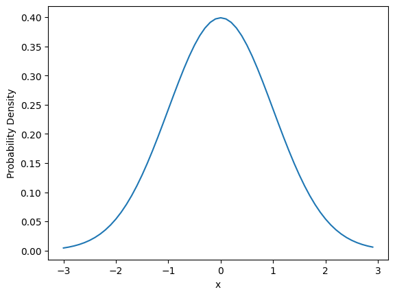

```python
#Create an array of uniformly spaced values
x = np.arange(-3,3,0.1)
#Create a list containing a distribution value for each value in x
# using list comprehension.
y = [standardNormalDistribution(val) for val in x]

#Use matplotlib to plot the data.
plt.plot(x,y)
plt.ylabel('Probability Density')
plt.xlabel('x')
plt.savefig("StatisticsPart02.01.png")
plt.show()
```

## Description of the image shown above, StatisticsPart02.01.png

### 1. Type of image

A line plot of the standard normal probability density function.

### 2. Overall summary

This image displays the bell-shaped curve of the standard normal distribution, centered at zero and extending from -3 to +3 on the horizontal axis. The curve is symmetric, highest at the mean, and tapers smoothly toward both ends, illustrating how probability density decreases as values move farther from the center.

### 3. Detailed description

The horizontal axis is labeled "x" and ranges from -3 on the left to +3 on the right. The vertical axis is labeled "Probability Density" and spans from 0.00 at the bottom to approximately 0.40 at the top. A single smooth curve forms a symmetric bell shape centered at x = 0, where the probability density reaches its maximum (just under 0.40). As x moves away from zero in either direction, the curve slopes downward gradually, approaching but never touching the horizontal axis near -3 and +3. The plot contains no additional markers, shading, or annotations—only the continuous curve and labeled axes.

### 4. Purpose of the image

The purpose of this image is to illustrate the standard normal probability density function over the range from -3σ to +3σ. It helps readers understand how probability density is distributed around the mean in a standard normal distribution, supporting discussions of z-scores, standardization, and the role of the normal distribution in statistical modeling and inference.

### Normal probabilty density function

Now let's define a function from which you can obtain values for the normal probability density curve for any input values of mu and sigma. See [Engineering Statistics Handbook](http://www.itl.nist.gov/div898/handbook/eda/section3/eda3661.htm) for a definition of the equation for the normal probability density function.

This function is more general than the similar function defined above. That function assumed that mu was equal to zero and sigma was equal to 1. Those assumptions result in a function commonly called the standard normal distribution. This function makes no such assumption and results in the more general probability density function.

```python
'''
Computes and return values for the normal probabilty density function

required input: x-axis value
optional input: mu
optional input: sigma

returns: The computed value of the function for the given x, mu, and sigma. If mu and sigma are not provided as
input arguments, the method reverts to returning values for the standard normal distribution curve with mu = 0
and sigma = 1.0
'''
def normalProbabilityDensity(x,mu=0,sigma=1.0):

    eVal = 2.718281828459045
    exp = -((x-mu)**2)/(2*(sigma**2))
    numerator = pow(eVal,exp)
    denominator = sigma*(math.sqrt(2*math.pi))
    return numerator/denominator
```

#### Plot it

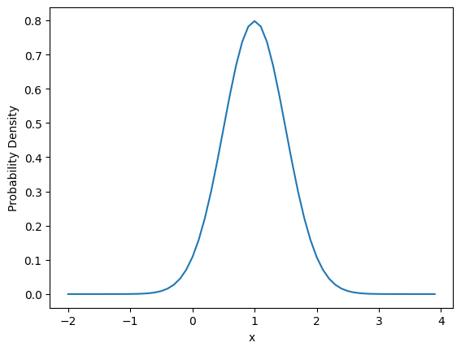

```python
x = np.arange(-2,4,0.1)
y = [normalProbabilityDensity(val,mu=1,sigma=0.5) for val in x]

#Use matplotlib to plot the data.
plt.plot(x,y)
plt.ylabel('Probability Density')
plt.xlabel('x')
plt.savefig("StatisticsPart02.02.png")
plt.show()
```

## Description of the image shown above, StatisticsPart02.02.png

### 1. Type of image

A line plot of a normal probability density function with mean μ = 1 and standard deviation σ = 0.5.

### Cumulative distribution function

Now define a utility function that will return the value of the cumulative normal distribution function. This function takes x as a parameter and returns the area under the standard normal distribution curve from minus infinity up to the value of x.

A call to this function is equivalent to finding a value in a Z-table.

The method for computing the cumulative probability in the following code came from [Stand-alone Python implementation of phi(x)](https://www.johndcook.com/blog/python_phi/) by John D. Cook.

```python
'''
Computes and returns values for the cumulative distribution function of the standard normal
probability density function. Stated differently, computes and returns area under the standard
normal curve from minus infinity to an input x value.

This is a series implementation. A digital numeric integration version is provided later in
this document for comparison.

input: x-axis value as a decimal fraction of the standard deviation
returns: The computed value of the function for the given x-axis value

Examples

x = -2, output = 0.022750062887256395
x = -1, output = 0.15865526383236372
x = 0, output = 0.5000000005
x = 1, output = 0.8413447361676363
x = 2, output = 0.9772499371127437

'''
def cumulativeDistribution(x):
    # constants
    a1 =  0.254829592
    a2 = -0.284496736
    a3 =  1.421413741
    a4 = -1.453152027
    a5 =  1.061405429
    p  =  0.3275911

    # Save the sign of x
    sign = 1
    if x < 0:
        sign = -1
    x = abs(x)/math.sqrt(2.0)

    # A&S formula 7.1.26
    t = 1.0/(1.0 + p*x)
    y = 1.0 - (((((a5*t + a4)*t) + a3)*t + a2)*t + a1)*t*math.exp(-x*x)

    return 0.5*(1.0 + sign*y)
```

#### Plot it

Get and plot the cumulative distribution from -3 sigma to +3 sigma.

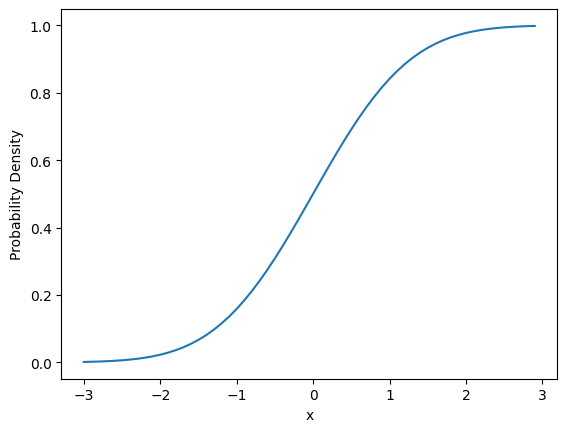

```python
x = np.arange(-3,3,0.1)
y = [cumulativeDistribution(val) for val in x]

#Use matplotlib to plot the data.
plt.plot(x,y)
plt.ylabel('Probability Density')
plt.xlabel('x')
plt.savefig("StatisticsPart02.03.png")
plt.show()
```

## Description of the image shown above, StatisticsPart02.03.png

### 1. Type of image

A line plot of the cumulative distribution function (CDF) of a normal distribution.

### 2. Overall summary

The image shows the S‑shaped cumulative distribution curve for a normal distribution evaluated from -3σ to +3σ. The curve begins near zero at the far left, rises gradually through the middle region, and approaches one at the far right, illustrating how cumulative probability accumulates across the distribution.

### 4. Purpose of the image

The purpose of this image is to illustrate the cumulative distribution function of a normal distribution over the range from -3σ to +3σ. It helps readers understand how cumulative probability increases across the distribution, supporting discussions of percentiles, probability accumulation, and the interpretation of CDFs in statistical analysis.

### A random dataset generator

Now define a utility function that returns a dataset of more or less normally distributed values. The returned dataset is uniformly distributed for an input keyword paramater value of numberSamples=1. The resulting dataset tends more towards normal as the value of numberSamples is increased.

```python
def normalRandomGenerator(seed=1,dataLength=10000,numberSamples=50,lowLim=0,highLim=100):
    '''
    Create a new dataset of dataLength values consisting of the average of numberSamples
    samples taken from a population of uniformly distributed values between lowLim
    and highLim generated with a seed of seed.

    Input keyword parameters and their default values:

    seed = 1 seed used to generate the uniformly distributed values
    dataLength = 10000 number of samples in the returned list of values
    numberSamples = 50 number of samples taken from the uniformly distributed population
                       and averaged into the output
    lowLim = 0 lower limit value of the uniformly distributed population
    highLim = 100 high limit value of the uniformly distributed population

    returns: a list containing the dataset

    '''
    data = []
    random.seed(seed)

    for cnt in range(dataLength):
        theSum = 0
        for cnt1 in range(numberSamples):
            theSum += random.uniform(lowLim,highLim)
        data.append(theSum/numberSamples)

    return data
```

### Least mean square best fit line

The following function will compute a least mean square best fit line for a scatter plot.

```python
def lmsBestFitLine(xDataIn,yDataIn):
    xBar = sum(xDataIn)/len(xDataIn)
    yBar = sum(yDataIn)/len(yDataIn)

    numerator = 0
    for cnt in range(len(xDataIn)):
        numerator += (xDataIn[cnt] - xBar) * (yDataIn[cnt] - yBar)

    denominator = 0
    for cnt in range(len(xDataIn)):
        denominator += (xDataIn[cnt] -xBar)**2

    m = numerator/denominator

    b = yBar - m*xBar

    return (m,b)#slope,y-intercept
```

### plotHistAndBox function

```python
'''
Plots a histogram and a "box and whisker" plot for
an incoming dataset on a 1x2 row of an incoming figure
specified by axes. The row index on which to plot the
data is specified by axesRow. Also creates and plots
a normal prpobability density curve on the histogram
based on the mean and standard deviation of the
dataset. Set multiDim to true if axes in a
multi-dimensional array.
'''

def plotHistAndBox(data,axes,axesRow=0,multiDim=False):

    dataBar = mean(data)
    dataStd = stdev(data)

    if multiDim == True:
        #Plot and label histogram
        dataN,dataBins,dataPat = axes[axesRow,0].hist(
            data,bins=136,density=True,range=(min(data),max(data)))
        axes[axesRow,0].set_title('data')
        axes[axesRow,0].set_xlabel('x')
        axes[axesRow,0].set_ylabel('Relative Freq')

        #Plot a boxplot
        axes[axesRow,1].boxplot(data,vert=False)
        axes[axesRow,1].set_title('Box and Whisker Plot')
        axes[axesRow,1].set_xlabel('x')

    else:
        #Plot and label histogram
        dataN,dataBins,dataPat = axes[0].hist(
            data,bins=136,density=True,range=(min(data),max(data)))
        axes[0].set_title('data')
        axes[0].set_xlabel('x')
        axes[0].set_ylabel('Relative Freq')

        #Plot a boxplot
        axes[1].boxplot(data,vert=False)
        axes[1].set_title('Box and Whisker Plot')
        axes[1].set_xlabel('x')

    #Compute the values for a normal probability density curve for the
    # data mu and sigma across the same range of values.
    x = np.arange(dataBins[0],dataBins[len(dataBins)-1],0.1)
    y = [normalProbabilityDensity(
        val,mu=dataBar,sigma=dataStd) for val in x]

    #Superimpose the normal probability density curve on the histogram.
    if multiDim == True:
        axes[axesRow,0].plot(x,y,label='normal probability density')
    else:
        axes[0].plot(x,y,label='normal probability density')
```

#### Plot it

Test the function named plotHistAndBox.

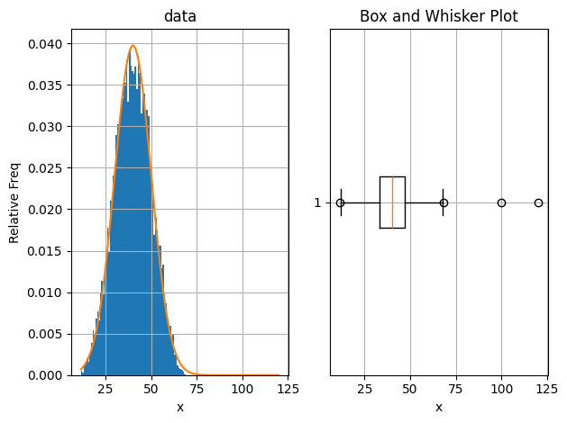

```python
#Create a normal dataset with outliers.
g01 = normalRandomGenerator(dataLength=9999,numberSamples=3,
    lowLim=10,highLim=70,seed=1) + [68.5] + [100] + [120]

#Create a figure with one row and two columns
fig,axes = plt.subplots(1,2)

#Call the plotHistAndBox function to plot the dataset
plotHistAndBox(g01,axes)

axes[0].grid(True)
axes[1].grid(True)
plt.tight_layout()
plt.savefig("StatisticsPart02.04.png")
plt.show()
```

## Description of the image shown above, StatisticsPart02.04.png

### 1. Type of image

A two‑panel figure containing a histogram with an overlaid density curve on the left and a box‑and‑whisker plot on the right.

### 2. Overall summary

The image presents two complementary visualizations of the same dataset. The histogram on the left shows the distribution of the data, including its overall shape and relative frequencies. The box‑and‑whisker plot on the right summarizes the central tendency, spread, and presence of outliers using quartile‑based statistics.

### 3. Detailed description

The left panel is a histogram labeled “data,” with the horizontal axis labeled “x” and the vertical axis labeled “Relative Freq.” The bars show a distribution with most values concentrated near the mid‑range and a tail extending to the right. A smooth orange density curve overlays the bars, following the same general pattern as the histogram and peaking near the tallest bars.

The right panel is a box‑and‑whisker plot labeled “Box and Whisker Plot,” using the same horizontal axis label “x.” The box represents the interquartile range, with a horizontal line marking the median. Whiskers extend to values within 1.5 times the interquartile range. Several individual points appear beyond the whiskers, indicating outliers. The plot is drawn at a constant vertical position, emphasizing that the horizontal axis represents the data values.

### 4. Purpose of the image

The purpose of this image is to test the function named `plotHistAndBox` by generating both a histogram and a box‑and‑whisker plot for the same dataset. Together, these visualizations help readers understand the distribution’s shape, central tendency, variability, and presence of outliers, illustrating how different graphical summaries complement one another in exploratory data analysis.

## General histogram Q & A

That's the end of the section containing utility functions. Let's begin this exercise page with a general question and answer session regarding the interpretation of histograms. Note that you are not expected to understand the code that generated the histograms at this point, but you should fully understand that code by the end of the course.

Assume that the two histograms that you see below represent the annual salaries earned by graduates with a History major on the left and graduates with a Data Science Programmer major on the right. **(Note that these histograms are based on totally fictitious data generated solely to illustrate the use of histograms in data analysis.)**

The orange curves that are superimposed on the blue histogram data are normal distribution curves.

The program also equates program code with looking up stardardized z values in a Z-table.

Questions (See the answers below the histograms.)

1. Approximately what income do most History majors and Data Science Programming majors make?
2. Is it reasonable to draw conclusions about this data by assuming that it is normally distributed?
3. What pecentage of History majors earn between 30 and 50 thousand per year?
4. What percentage of Data Science majors earn between 55 and 65 thousand per year?
5. Of the population on which the histogram is based, approximately how many History majors make less than 40,000 per year.
6. Of the population on which the histogram is based, approximately how many Data Science majors make more than 40,000 per year.

```
Number of History values = 4362
Number of Data Science values 5123
histBar = 39.90199979054073
dSciBar = 59.99548093874471
histStd = 10.064284837901639
dSciStd = 5.479641868832745

Approximately 68 percent of History majors earn between 30 and 50 thousand
per year with an average of 40 thousand per year.


Compare the following with looking up values in a Z-table
zHigh = 1.0000000000000009
cumulativeDistribution(zHi) = 0.8413447361676365
zLow = -0.9999999999999997
cumulativeDistribution(zLo) = 0.1586552638323639

Approximately 68 percent of Data Science majors earn between 55 and 65 thousand
per year with an average of 60 thousand per year.

Approximately 2198 history majors, 50 percent, make less than 40 thousand per year.

Approximately 5122 Data Science majors, 100 percent, make more than 40 thousand per year.
```

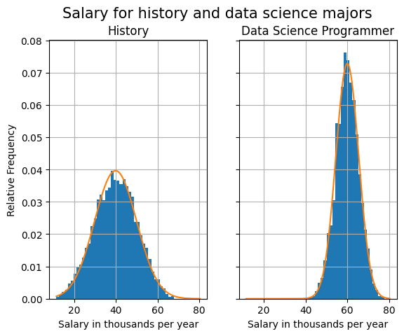

```python
history = normalRandomGenerator(dataLength=4362,numberSamples=3,lowLim=10,highLim=70,seed=1)
dSci = normalRandomGenerator(dataLength=5123,numberSamples=10,lowLim=30,highLim=90,seed=2)

print("Number of History values =",len(history))
print("Number of Data Science values",len(dSci))
histBar = mean(history)
print("histBar =",histBar)
dSciBar = mean(dSci)
print("dSciBar =",dSciBar)
histStd = stdev(history)
print("histStd =", histStd)
dSciStd = stdev(dSci)
print("dSciStd =", dSciStd)


#Standardize and lookup
print()
x = (((histBar + histStd)-histBar)/histStd)
y = (((histBar - histStd)-histBar)/histStd)
histMidRange = cumulativeDistribution(x)-cumulativeDistribution(y)

print('Approximately',int(100*histMidRange), 'percent of History majors earn between',\
      round(histBar - histStd),'and',round(histBar + histStd),'thousand \nper year',\
     'with an average of',round(histBar),'thousand per year.')

print()
x = (((dSciBar + dSciStd)-dSciBar)/dSciStd)
y = (((dSciBar - dSciStd)-dSciBar)/dSciStd)
dSciMidRange = cumulativeDistribution(x)-cumulativeDistribution(y)

print()
print("Compare the following with looking up values in a Z-table")
print("zHigh =",x)
print("cumulativeDistribution(zHi) =",cumulativeDistribution(x))
print("zLow =",y)
print("cumulativeDistribution(zLo) =",cumulativeDistribution(y))
print()

print('Approximately',int(100*histMidRange), 'percent of Data Science majors earn between',\
      round(dSciBar - dSciStd),'and',round(dSciBar + dSciStd),'thousand \nper year',\
     'with an average of',round(dSciBar),'thousand per year.')

print()
x = (round(histBar)-histBar)/histStd
ltHistMean = cumulativeDistribution(x)
print("Approximately", round(ltHistMean * len(history)),\
      "history majors,",round(100*ltHistMean) ,"percent, make less than",round(histBar),"thousand per year.")

print()
x = (round(histBar)-dSciBar)/dSciStd
gtHistMean = 1 - cumulativeDistribution(x)
#gtHistMean = 1 - normalProbability(round(histBar),mu=dSciBar,sigma=dSciStd)
print("Approximately", round(gtHistMean * len(dSci)),\
      "Data Science majors,",round(100*gtHistMean) ,"percent, make more than",round(histBar),"thousand per year.")

fig,axes = plt.subplots(1,2,sharey=True)
histN,histBins,histPat = axes[0].hist(history,bins=50,density=True,range=(min(history),max(dSci)))
axes[0].set_title('History')
axes[0].set_xlabel('Salary in thousands per year')
axes[0].set_ylabel('Relative Frequency')


dSciN,dSciBins,dSciPat = axes[1].hist(dSci,bins=50,density=True,range=(min(history),max(dSci)))
axes[1].set_title('Data Science Programmer')
axes[1].set_xlabel('Salary in thousands per year')
axes[0].grid(True)
axes[1].grid(True)


#Compute the values for a normal probability density curve for the
# history mu and sigma across the same range of values.
x = np.arange(histBins[0],histBins[len(histBins)-1],0.1)
y = [normalProbabilityDensity(val,mu=histBar,sigma=histStd) for val in x]

#Superimpose the normal probability density curve on the histogram.
axes[0].plot(x,y,label='normal probability density')


#Compute the values for a normal probability density curve for the
# dSci mu and sigma across the same range of values.
x = np.arange(dSciBins[0],dSciBins[len(dSciBins)-1],0.1)
y = [normalProbabilityDensity(val,mu=dSciBar,sigma=dSciStd) for val in x]

#Superimpose the normal probability density curve on the histogram.
axes[1].plot(x,y,label='normal probability density')

fig.suptitle('Salary for history and data science majors', fontsize=15)
plt.savefig("StatisticsPart02.05.png")
plt.show()
```

## Description of the image shown above, StatisticsPart02.05.png

### 1. Type of image

A two‑panel figure containing histograms with overlaid normal curves, comparing salary distributions for two hypothetical different academic majors.

### 2. Overall summary

The figure displays two histograms side by side. The left panel shows the hypothetical salary distribution for History majors, while the right panel shows the hypothetical salary distribution for Data Science Programming majors. Both histograms include smooth orange curves representing normal distributions fitted to the data. The two panels allow readers to visually compare typical salaries, variability, and distribution shapes across the two majors.

### 3. Detailed description

The title at the top of the figure reads “Salary for history and data science majors.”  
Both panels share the same axis labels: the horizontal axis is labeled “Salary in thousands per year,” and the vertical axis is labeled “Relative Frequency.”

### 4. Purpose of the image

The purpose of this image is to support a question‑and‑answer exercise on interpreting histograms. The figure provides two contrasting salary distributions—one for History majors and one for Data Science Programming majors—allowing readers to practice identifying typical values, assessing distribution shapes, and estimating percentages within given ranges. The overlaid normal curves illustrate how program code can approximate standardized z‑value calculations, even though the underlying data may not be perfectly normal. This visualization prepares readers for later lessons in statistical modeling, distributional assumptions, and the interpretation of empirical data.

Answers to questions:

1. Approximately what income do most History majors and Data Science Programming majors make? (See the histBar and the dSciBar in the output for quick answers. We will see better answers later based on the standard deviation.)
2. Is it reasonable to draw conclusions about this data by assuming that it is normally distributed? Yes. The orange normal curves that are superimposed on the histograms indicate that the distribution of the data is very close to normal.
3. What pecentage of History majors earn between 30 and 50 thousand per year? See the answer in the printed output. This is also a better answer to the first question.
4. What percentage of Data Science majors earn between 55 and 65 thousand per year? See the answer in the printed output. This is also a better answer to the first question.
5. Of the population on which the histogram is based, approximately how many History majors make less than 40,000 per year. See the printed output.
6. Of the population on which the histogram is based, approximately how many Data Science majors make more than 40,000 per year. See the printed output.

## Detrimental impact of an outlier

Assume that salary surveys are conducted for two equal size groups of history majors. The first group is a typical group of history majors. However, the second group includes one individual who lands a football contract with the NFL and earns a huge salary his first year out of college and into the indefinite future. This large salary is what is commonly known as an outlier.

Statistics are computed and histograms are plotted for both groups. Here are some observations.

The presence of outliers in datasets can be very detrimental to statistical analysis. Unless outliers are representative of the typical state of the data being analyzed, they should probably be removed before undertaking a statistical analysis of the data.

**(Note that these analyses are based on totally fictitious data generated solely to illustrate the impact of an outlier in statistical data analysis.)**

```
Number of g01 values = 201
Number of g02 values = 201
g01Bar = 40.33801352003058
g02Bar = 44.948923653598015
g01Std = 10.330463182121866
g02Std = 68.52185410619977
g01Median = 40.3739234746022
g02Median = 41.339359378750395
```

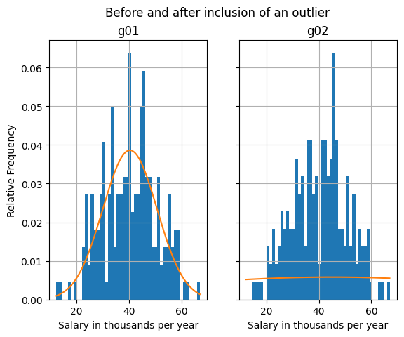

```python
#Create a normal dataset
g01 = normalRandomGenerator(dataLength=201,numberSamples=3,lowLim=10,highLim=70,seed=1)

#Create a normal dataset with an outlier
g02 = normalRandomGenerator(dataLength=200,numberSamples=3,lowLim=10,highLim=70,seed=2)+ [1000]

#Compute and print statistics for both datasets
print("Number of g01 values =",len(g01))
print("Number of g02 values =",len(g02))

g01Bar = mean(g01)
print("g01Bar =",g01Bar)

g02Bar = mean(g02)
print("g02Bar =",g02Bar)

g01Std = stdev(g01)
print("g01Std =", g01Std)

g02Std = stdev(g02)
print("g02Std =", g02Std)

g01Median = median(g01)
print("g01Median =",g01Median)

g02Median = median(g02)
print("g02Median =",g02Median)

#Plot and label histograms for both datasets for same range with a shared vertical axis.
fig,axes = plt.subplots(1,2,sharey=True)

g01N,g01Bins,g01Pat = axes[0].hist(g01,bins=50,density=True,range=(min(g01),max(g01)))
axes[0].set_title('g01')
axes[0].set_xlabel('Salary in thousands per year')
axes[0].set_ylabel('Relative Frequency')

g02N,g02Bins,g02Pat = axes[1].hist(g02,bins=50,density=True,range=(min(g01),max(g01)))
axes[1].set_title('g02')
axes[1].set_xlabel('Salary in thousands per year')

axes[0].grid(True)
axes[1].grid(True)


#Compute the values for a normal probability density curve for the
# g01 mu and sigma across the same range of values.
x = np.arange(g01Bins[0],g01Bins[len(g01Bins)-1],0.1)
y = [normalProbabilityDensity(val,mu=g01Bar,sigma=g01Std) for val in x]

#Superimpose the normal probability density curve on the g01ogram.
axes[0].plot(x,y,label='normal probability density')

#Compute the values for a normal probability density curve for the
# g02 mu and sigma across the same range of values.
x = np.arange(g01Bins[0],g01Bins[len(g01Bins)-1],0.1)
y = [normalProbabilityDensity(val,mu=g02Bar,sigma=g02Std) for val in x]

#Superimpose the normal probability density curve on the histogram.
axes[1].plot(x,y,label='normal probability density')

fig.suptitle('Before and after inclusion of an outlier', fontsize=12)
plt.savefig("StatisticsPart02.06.png")
plt.show()
```

## Description of the image shown above, StatisticsPart02.06.png

### 1. Type of image

A two‑panel figure containing histograms with overlaid normal curves, comparing a dataset before and after the inclusion of an outlier.

### 2. Overall summary

The figure shows how adding a single extremely large value to a dataset affects its distribution. The left histogram represents the original dataset, while the right histogram represents the same dataset after an outlier has been added. The overlaid normal curves illustrate how the mean and standard deviation change in response to the outlier, altering the shape and scale of the fitted distribution.

### 3. Detailed description

The title at the top of the figure reads “Before and after inclusion of an outlier.”  
Both panels share the same axis labels: the horizontal axis is labeled “Salary in thousands per year,” and the vertical axis is labeled “Relative Frequency.”

**Left panel (g01):**  
The histogram shows a roughly symmetric distribution of salaries. The bars form a shape that resembles a normal distribution, and a smooth orange curve overlays the bars, closely matching the overall pattern of the data.

**Right panel (g02):**  
This histogram displays the same general salary distribution but with one extremely large value added to the dataset. The overlaid orange curve is noticeably flatter and wider than the curve in the left panel. This change reflects the increased mean and greatly increased standard deviation caused by the outlier. The histogram bars themselves remain similar to those in the left panel, since the outlier is far outside the plotted range and does not appear as a bar.

### 4. Purpose of the image

The purpose of this image is to illustrate the detrimental impact of an outlier on statistical analysis. The figure supports a discussion of how a single extreme value can:

- Increase the mean by a substantial percentage
- Inflate the standard deviation by a large factor
- Distort a fitted normal curve so that it no longer represents the bulk of the data
- Leave the median largely unchanged unless the median value itself is replaced

This visualization reinforces the idea that outliers can severely mislead analyses based on the mean and standard deviation. When outliers are not representative of the typical data, they should generally be removed before performing statistical modeling or drawing conclusions. The example uses entirely fictitious data to demonstrate these effects in a controlled instructional setting.

## Order of mean and median for skewed distributions

What is the relationship between the mean and the median for a skewed distribution? The following code indicates experimentally that:

- The mean is greater than the median for a positively skewed distribution.
- The mean and the median are greater than the mode for a positively skewed distribution.
- The median is greater than the mean for a negatively skewed distribution.
- The mean and the median are less than the mode for a negatively skewed distribution.

```
Number of g01 values = 39
Number of g02 values = 39

g01Bar = 13.256410256410257
g01Median = 13

g02Bar = 14.743589743589743
g02Median = 15
```

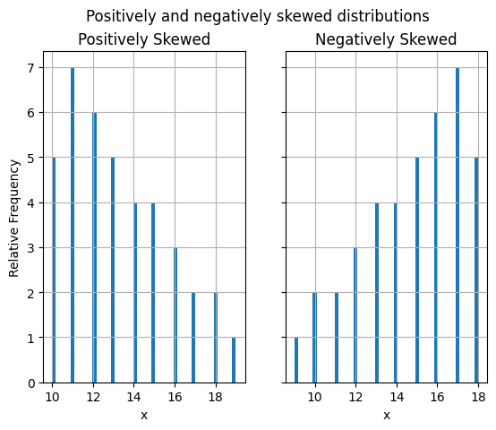

```python
#Create a positively skewed dataset.
g01 = [10,10,10,10,10,11,11,11,11,11,11,11,12,12,12,12,12,12,13,13,\
       13,13,13,14,14,14,14,15,15,15,15,16,16,16,17,17,18,18,19]

#Create a negatively skewed dataset
g02 = [18,18,18,18,18,17,17,17,17,17,17,17,16,16,16,16,16,16,15,15,\
       15,15,15,14,14,14,14,13,13,13,13,12,12,12,11,11,10,10,9]

#Compute and print statistics for both datasets
print("Number of g01 values =",len(g01))
print("Number of g02 values =",len(g02))

print()
g01Bar = mean(g01)
print("g01Bar =",g01Bar)
g01Median = median(g01)
print("g01Median =",g01Median)

print()
g02Bar = mean(g02)
print("g02Bar =",g02Bar)
g02Median = median(g02)
print("g02Median =",g02Median)

#Plot and label histograms for both datasets for same range with a shared vertical axis.
fig,axes = plt.subplots(1,2,sharey=True)

axes[0].hist(g01,bins=50,range=(min(g01),max(g01)))
axes[0].set_title('Positively Skewed')
axes[0].set_xlabel('x')
axes[0].set_ylabel('Relative Frequency')

axes[1].hist(g02,bins=50,range=(min(g02),max(g02)))
axes[1].set_title('Negatively Skewed')
axes[1].set_xlabel('x')

axes[0].grid(True)
axes[1].grid(True)

fig.suptitle('Positively and negatively skewed distributions', fontsize=12)
plt.savefig("StatisticsPart02.07.png")
plt.show()
```

## Description of the image shown above, StatisticsPart02.07.png

### 1. Type of image

A two‑panel bar chart illustrating positively skewed and negatively skewed distributions.

### 2. Overall summary

The figure compares two examples of skewed distributions. The left panel shows a positively skewed distribution, where most values occur on the lower end of the scale with a long tail extending to the right. The right panel shows a negatively skewed distribution, where most values occur on the higher end of the scale with a long tail extending to the left. These visualizations support a discussion of how the mean, median, and mode relate to one another in skewed distributions.

### 3. Detailed description

The title at the top of the figure reads “Positively and negatively skewed distributions.”  
Both panels share the same axis labels: the horizontal axis is labeled “x,” and the vertical axis is labeled “Relative Frequency.”

**Left panel (Positively Skewed):**  
The bars are tallest on the left side of the plot, around lower x‑values, and gradually decrease in height as x increases. This creates a distribution with most observations clustered at the lower end and a long tail extending to the right.

**Right panel (Negatively Skewed):**  
The bars are shortest on the left side and increase in height toward the right side of the plot. Most observations occur at higher x‑values, with a long tail extending to the left.

### 4. Purpose of the image

The purpose of this image is to illustrate the relationship between skewness and the ordering of the mean, median, and mode. The accompanying discussion explains that:

- For a **positively skewed** distribution, the mean is greater than the median, and both are greater than the mode.
- For a **negatively skewed** distribution, the median is greater than the mean, and both are less than the mode.

These visual examples help readers understand how skewness affects measures of central tendency and why the mean may not always be the best indicator of the “center” of a distribution.

## Relationship of mean, median, and mode for a normal distribution

Theoretically, the mean, the median, and the mode are all equal for a dataset with a normal distribution. While it is probably not possible to create a dataset with a perfectly normal distribution, we can come close.

The following code creates a dataset that is very close to normally distributed and shows that the mean and the median are very close to being equal. By observation of the histogram, we can see that the mode is also very close to being equal to the mean and the median.

```
Number of g01 values = 100000
g01Bar = -0.00880052373591947
g01Median = -0.026064678991148327
g01Std = 12.923823719960344
```

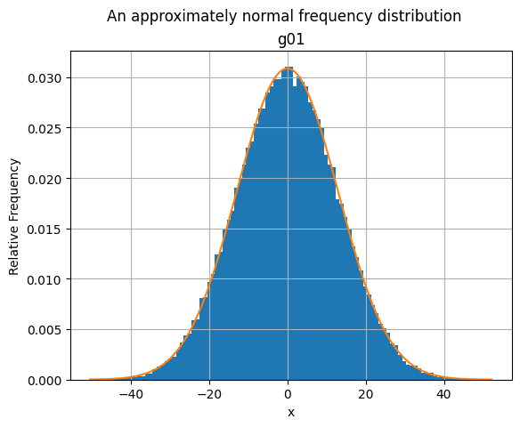

```python
#Create a nearly normal dataset
g01 = normalRandomGenerator(dataLength=100000,numberSamples=20,lowLim=-100,highLim=100)

#Compute and print statistics for the dataset
print("Number of g01 values =",len(g01))

g01Bar = mean(g01)
print("g01Bar =",g01Bar)

g01Median = median(g01)
print("g01Median =",g01Median)

g01Std = stdev(g01)
print("g01Std =", g01Std)

#Plot and label a histogram for the dataset
fig,axes = plt.subplots(1,1)

g01N,g01Bins,g01Pat = axes.hist(g01,bins=round(max(g01) - min(g01)),\
                                density=True,range=(min(g01),max(g01)))
axes.set_title('g01')
axes.set_xlabel('x')
axes.set_ylabel('Relative Frequency')

axes.grid(True)

#Compute the values for a normal probability density curve for the
# g01 mu and sigma across the same range of values.
x = np.arange(g01Bins[0],g01Bins[len(g01Bins)-1],0.1)
y = [normalProbabilityDensity(val,mu=g01Bar,sigma=g01Std) for val in x]

#Superimpose the normal probability density curve on the histogram.
axes.plot(x,y,label='normal probability density')

fig.suptitle('An approximately normal frequency distribution', fontsize=12)
plt.savefig("StatisticsPart02.08.png")
plt.show()
```

## **Description of the image shown above, StatisticsPart02.08.png**

### 1. Type of image

A histogram with an overlaid normal distribution curve, illustrating an approximately normal frequency distribution.

### 2. Overall summary

The image shows a symmetric, bell‑shaped distribution centered near zero. The histogram bars form a shape that closely resembles a normal distribution, and the smooth orange curve overlays the bars to highlight how well the empirical data matches the theoretical model. This visualization supports a discussion of the relationship among the mean, median, and mode for a nearly normal dataset.

### 3. Detailed description

The title at the top of the figure reads “An approximately normal frequency distribution,” with a subtitle “g01.”  
The horizontal axis is labeled “x,” and the vertical axis is labeled “Relative Frequency.”

The histogram bars are centered around zero and extend symmetrically to both the left and right. The tallest bars appear near the center, and the bar heights gradually decrease as the values move away from zero. A smooth orange curve overlays the histogram, forming a classic bell shape that closely matches the distribution of the bars. The curve peaks at the center and tapers smoothly toward both ends, indicating that the dataset is very close to normally distributed.

### 4. Purpose of the image

The purpose of this image is to illustrate that for a dataset that is very close to normally distributed, the mean, median, and mode are nearly equal. The accompanying text explains that:

- Theoretically, the mean, median, and mode are identical for a perfectly normal distribution.
- Real datasets rarely achieve perfect normality, but large samples can approximate it closely.
- In this example, the computed values
  - Mean (g01Bar): −0.0088005237
  - Median (g01Median): −0.0260646790
  - Standard deviation (g01Std): 12.92382372  
    are extremely close to what would be expected for a normal distribution centered near zero.

This visualization helps readers understand how measures of central tendency behave under normality and why the mean, median, and mode converge when the distribution is symmetric and bell‑shaped.

## Cutting off the tails

One of the ways that statisticians deal with outliers is to cut the tails off of the distribution. Apparently it is common practice to discard the lowest 25% of values and the highest 25% of values keeping only the Interquartile Range (IQR). The IQR contains two quarters or 50% of the data values.

The following code shows one way to do that and then plots histograms of the original dataset and the clipped dataset. Various statistics for both datasets are also computed and printed.

```
sum of original dataset 400254.2526316937
sum of clipped dataset 200247.76147012415
sum of two center quartiles 200247.76147012413
sum of firstQuartile 67992.58275313118
sum of secondQuartile 91499.77733209946
sum of thirdQuartile 108747.98413802468
sum of fourthQuartile 132013.90840843835
Number of g01 values = 10000
Number of g02 values = 5000
g01 range = 68.47115817252995
g02 range = 14.149366557701335

g01Bar = 40.02542526316937
g02Bar = 40.04955229402483
g01Std = 9.996694607203745
g02Std = 4.001927446346313
g01Median = 40.01678513788222
g02Median = 40.01678513788222
```

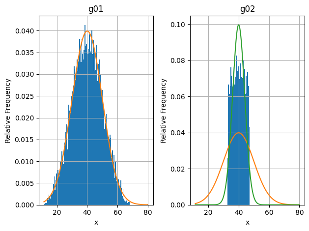

```python
#Create a normal dataset with an outlier
g01 = normalRandomGenerator(dataLength=9999,numberSamples=3,lowLim=10,highLim=70,seed=1) + [80]

#Sort the dataset to make it possible to divide the data values into quartiles.
g01.sort()

#Create a dataset by discarding the top 25% and the bottom 25% of the values in the original dataset.

#Use the median to subdivide the data into halves. Use Python list comprehension
g01Median = median(g01)
topHalf = [x for x in g01 if x >= g01Median]
bottomHalf = [x for x in g01 if x < g01Median]

#Get the median for each half
topHalfMedian = median(topHalf)
bottomHalfMedian = median(bottomHalf)

#Use the medians to divide the halves into halves, or into quartiles
firstQuartile = [x for x in bottomHalf if x < bottomHalfMedian]
secondQuartile = [x for x in bottomHalf if x >= bottomHalfMedian]
thirdQuartile = [x for x in topHalf if x <= topHalfMedian]
fourthQuartile = [x for x in topHalf if x > topHalfMedian]

#Concatenate the two center quartiles to become the new dataset
g02 = secondQuartile + thirdQuartile


#Compute and print statistics for both datasets
print()
print("sum of original dataset",sum(g01))
print("sum of clipped dataset",sum(g02))
print("sum of two center quartiles",sum(secondQuartile)+sum(thirdQuartile))

print("sum of firstQuartile",sum(firstQuartile))
print("sum of secondQuartile",sum(secondQuartile))
print("sum of thirdQuartile",sum(thirdQuartile))
print("sum of fourthQuartile",sum(fourthQuartile))

print("Number of g01 values =",len(g01))
print("Number of g02 values =",len(g02))

print("g01 range =",max(g01) - min(g01))
print("g02 range =",max(g02) - min(g02))
print()

g01Bar = mean(g01)
print("g01Bar =",g01Bar)

g02Bar = mean(g02)
print("g02Bar =",g02Bar)

g01Std = stdev(g01)
print("g01Std =", g01Std)

g02Std = stdev(g02)
print("g02Std =", g02Std)

g01Median = median(g01)
print("g01Median =",g01Median)

g02Median = median(g02)
print("g02Median =",g02Median)

#Plot and label histograms for both datasets
fig,axes = plt.subplots(1,2)

g01N,g01Bins,g01Pat = axes[0].hist(g01,bins=136,density=True,range=(min(g01),max(g01)))
axes[0].set_title('g01')
axes[0].set_xlabel('x')
axes[0].set_ylabel('Relative Frequency')

g02N,g02Bins,g02Pat = axes[1].hist(g02,bins=136,density=True,range=(min(g01),max(g01)))
axes[1].set_title('g02')
axes[1].set_xlabel('x')
axes[1].set_ylabel('Relative Frequency')

axes[0].grid(True)
axes[1].grid(True)

#Compute the values for a normal probability density curve for the
# g01 mu and sigma across the same range of values and
# superimpose the normal probability density curve on the histogram.
x = np.arange(g01Bins[0],g01Bins[len(g01Bins)-1],0.1)
y = [normalProbabilityDensity(val,mu=g01Bar,sigma=g01Std) for val in x]
axes[0].plot(x,y,label='normal probability density')

#Superimpose the normal probability density curve for g01 on the histogram for g02.
axes[1].plot(x,y,label='normal probability density')

#Compute the values for a normal probability density curve for the
# g02 mu and sigma across the same range of values and
# superimpose the normal probability density curve on the histogram.
y = [normalProbabilityDensity(val,mu=g02Bar,sigma=g02Std) for val in x]
plt.plot(x,y)

plt.tight_layout()
plt.savefig("StatisticsPart02.09.png")
plt.show()
```

## **Description of the image shown above, StatisticsPart02.09.png**

### 1. Type of image

A two‑panel figure containing histograms with overlaid normal distribution curves, comparing an original dataset with a clipped (IQR‑only) dataset.

### 2. Overall summary

The figure shows how removing the lowest 25% and highest 25% of values—keeping only the interquartile range (IQR)—changes the shape of a distribution. The left panel displays the histogram of the full dataset, while the right panel displays the histogram of the clipped dataset. Two normal curves are drawn on the clipped histogram to illustrate how the distribution changes when the tails are removed.

### 3. Detailed description

The left panel is labeled “g01.” It shows a histogram centered near a value of 40, with a smooth orange normal curve overlaid. The distribution is moderately wide, with bars extending across a broad range of x‑values. The orange curve matches the histogram closely, indicating that the original dataset is approximately normal.

The right panel is labeled “g02.” It shows the histogram of the clipped dataset, which contains only the middle 50% of the original values. The histogram is more sharply peaked and narrower than the original. Two curves are drawn on top:

The green curve is noticeably narrower and taller, reflecting the reduced spread of the clipped data. The orange curve is wider, showing how much information was removed when the tails were discarded.

Both panels share the same axis labels:

- Horizontal axis: “x”
- Vertical axis: “Relative Frequency”

### 4. Purpose of the image

The printed statistics reinforce these observations:

- Sum of original dataset: 400254.2526
- Sum of clipped dataset: 200247.7615
- Sum of two center quartiles: 200247.7615
- g01 (original) count: 10000
- g02 (clipped) count: 5000
- g01 range: 68.47
- g02 range: 14.15
- g01 mean: 40.0254
- g02 mean: 40.0496
- g01 standard deviation: 9.9967
- g02 standard deviation: 4.0019
- g01 median: 40.0168
- g02 median: 40.0168

This visualization helps readers understand that when statisticians remove outliers by clipping to the IQR only, doing so affects distribution shape, variability, and the interpretation of summary statistics.

## Outliers and quartiles

To understand the definition of an outlier, you must first understand quartiles. You can divide the dataset into quartiles with the following procedure:

1. Sort the dataset into ascending order.
2. Find the median of the dataset.
3. Divide the dataset into two halves at the median.
4. Find the median of each half.
5. Going from smaller to larger, label the three median values as Q1, Q2, and Q3
6. Compute the Interquartile Range (IQR) as Q3 - Q1.

Any value x is an outlier if either of the following is true:

- x < Q1 - 1.5*IQR
- x > Q3 + 1.5*IQR

The following code creates a relatively normal dataset with two outliers. One outlier on the high end was put there on purpose. The other outlier on the low end resulted from the averaging procedure used to create the dataset.

Then the program computes and prints several values using the above procedure including the IRQ and the lower and upper outlier limits. The program also displays the mean and the standard deviation for the dataset.

Then the program plots a histogram for the dataset and plots a normal distribution curve on the histogram.

If you understand how the x-axis scale is determined for the histogram, you can tell by viewing the histogram that there is an outlier with a value of approximately 120. However, the outlier at the low end isn't obvious because it is barely below the lower outlier limit. You will see later how I knew that it was there.

```
Q1 = 32.98235916117212
Q2 = 40.01678513788222
Q3 = 47.13997603963223
IQR = 14.15761687846011
lowerOutlierLimit = 11.745933843481954
upperOutlierLimit 68.3764013573224

g01Bar = 40.029425263169365
g01Std = 10.020665229936041
```

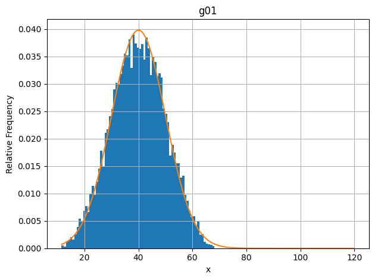

```python
#Create a normal dataset with an outlier
g01 = normalRandomGenerator(dataLength=9999,numberSamples=3,lowLim=10,highLim=70,seed=1) + [120]

#Sort the dataset to make it possible to divide the data values into quartiles.
g01.sort()

#Use the median to subdivide the data into halves. Use Python list comprehension
Q2 = median(g01)
topHalf = [x for x in g01 if x >= Q2]
bottomHalf = [x for x in g01 if x < Q2]

#Get the median for each half
Q3 = median(topHalf)
Q1 = median(bottomHalf)
IQR = Q3 - Q1
lowerOutlierLimit = Q1 - 1.5*IQR
upperOutlierLimit = Q3 + 1.5*IQR

print("Q1 =",Q1)
print("Q2 =",Q2)
print("Q3 =",Q3)
print("IQR =",IQR)
print("lowerOutlierLimit =",lowerOutlierLimit)
print("upperOutlierLimit",upperOutlierLimit)

print()

g01Bar = mean(g01)
print("g01Bar =",g01Bar)

g01Std = stdev(g01)
print("g01Std =", g01Std)

#Plot and label histogram
fig,axes = plt.subplots(1,1)

g01N,g01Bins,g01Pat = axes.hist(g01,bins=136,density=True,range=(min(g01),max(g01)))
axes.set_title('g01')
axes.set_xlabel('x')
axes.set_ylabel('Relative Frequency')

axes.grid(True)

#Compute the values for a normal probability density curve for the
# g01 mu and sigma across the same range of values and
# superimpose the normal probability density curve on the histogram.
x = np.arange(g01Bins[0],g01Bins[len(g01Bins)-1],0.1)
y = [normalProbabilityDensity(val,mu=g01Bar,sigma=g01Std) for val in x]
axes.plot(x,y,label='normal probability density')

plt.tight_layout()
plt.savefig("StatisticsPart02.10.png")
plt.show()
```

## **Description of the image shown above, StatisticsPart02.10.png**

### 1. Type of image

A histogram with an overlaid normal distribution curve, illustrating a dataset that contains two outliers and the quartile‑based method used to detect them.

### 2. Overall summary

The figure shows the distribution of a dataset labeled “g01.” The histogram displays the relative frequencies of the data values, and a smooth orange curve overlays the bars to represent a fitted normal distribution. The plot supports a discussion of quartiles, the interquartile range (IQR), and how outliers are identified using the standard 1.5×IQR rule.

### 3. Detailed description

The axes are labeled:

- Horizontal axis: “x”
- Vertical axis: “Relative Frequency”

### 4. Purpose of the image

The purpose of this image is to illustrate how quartiles and the interquartile range (IQR) are used to identify outliers. The accompanying explanation walks through the standard procedure:

- Sort the dataset
- Compute the median (Q2)
- Split the dataset into two halves
- Compute Q1 and Q3
- Compute the IQR as Q3 − Q1
- Determine outlier limits using
  - Lower limit: Q1 − 1.5×IQR
  - Upper limit: Q3 + 1.5×IQR

The printed values from the program are:

- Q1 = 32.98235916117212
- Q2 = 40.01678513788222
- Q3 = 47.13997603963223
- IQR = 14.15761687846011
- Lower outlier limit = 11.745933843481954
- Upper outlier limit = 68.3764013573224

The dataset also includes summary statistics:

- Mean (g01Bar) = 40.029425263169365
- Standard deviation (g01Std) = 10.020665229936043

The visualization helps readers understand how outliers affect the distribution and how the IQR method identifies them. The high‑end outlier near 120 is barely visible, while the low‑end outlier is subtle because it lies only slightly below the lower limit. This example reinforces the importance of quartile‑based methods in exploratory data analysis.

## Box and whisker plots

### Box and whisker Example 1

In an earlier exercise, I told you that the dataset being analyzed has an outlier very close to the lower outlier limit that was not obvious by viewing the histogram. I promised to tell you later how I knew it was there.

You learned how to compute the lower and upper outlier limits in that exercise.

Then the program computes and prints several values including the IRQ and the lower and upper outlier limits. The program also displays the mean and the standard deviation for the dataset.

Then the program plots a histogram for the dataset and plots a normal distribution curve on the histogram.

Finally, and this is new to this exercise, the program plots a "box and whisker" plot for the data. Box and whisker plots are ideal for comparing distributions because the center, the spread, and the overall range are immediately apparent, as are the outliers.

Think of the horizontal center line as repesenting the full range of the data with low values at the left and high values at the right. (The plot can also be oriented vertically with high values at the top.) The three small circles at the right represent the three outliers that I added to the normal dataset for illustration purposes. The small circle on the left represents a low-end outlier that was a normal consequence of the manner in which the dataset was created. (This is how I knew that there is an outlier at the low end.)

The red vertical line represents the median of the dataset or Q2. The left end of the box represents Q1 and the right end of the box represents Q3. The width of the box represents the IRQ.

The short vertical lines to the left and right of the box appear to represent the lower and upper outlier limits respectively although this is not obvious in the MatPlotLib documentation. This can, however, be demonstrated experimentally. I added an outlier with a value of 68.5 and the short vertical line on the right is almost centered on the circle that represents that outlier. The computed value of the upper outlier limit is 68.43, only slightly less than the value of the outlier that I added to the dataset. Thus the position of the short vertical line is a close match to the value of the upper outlier limit.

```
Q1 = 32.98790609425962
Q2 = 40.019366586363226
Q3 = 47.164764357178534
IQR = 14.176858262918913
lowerOutlierLimit = 11.722618699881252
upperOutlierLimit 68.4300517515569
min = 11.52884182747004
max = 120

g01Bar = 40.03826760964744
g01Std = 10.041625017758173
```

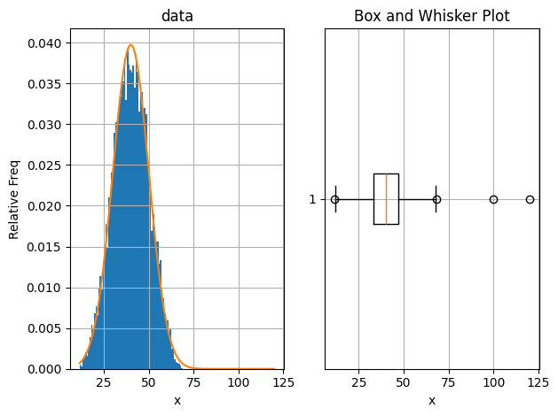

```python
#Create a normal dataset with outliers.
g01 = normalRandomGenerator(dataLength=9999,numberSamples=3,lowLim=10,highLim=70,seed=1) + [68.5] + [100] + [120]

#Sort the dataset to make it possible to divide the data values into quartiles.
g01.sort()

#Use the median to subdivide the data into halves. Use Python list comprehension
Q2 = median(g01)
topHalf = [x for x in g01 if x >= Q2]
bottomHalf = [x for x in g01 if x < Q2]

#Get the median for each half
Q3 = median(topHalf)
Q1 = median(bottomHalf)
IQR = Q3 - Q1
lowerOutlierLimit = Q1 - 1.5*IQR
upperOutlierLimit = Q3 + 1.5*IQR

print("Q1 =",Q1)
print("Q2 =",Q2)
print("Q3 =",Q3)
print("IQR =",IQR)
print("lowerOutlierLimit =",lowerOutlierLimit)
print("upperOutlierLimit",upperOutlierLimit)
print("min =",min(g01))
print("max =",max(g01))

print()

g01Bar = mean(g01)
print("g01Bar =",g01Bar)

g01Std = stdev(g01)
print("g01Std =", g01Std)

#Create a figure with one row and two columns
fig,axes = plt.subplots(1,2)

#Call the plotHistAndBox function to plot the dataset
plotHistAndBox(g01,axes)

axes[0].grid(True)
axes[1].grid(True)
plt.tight_layout()
plt.savefig("StatisticsPart02.11.png")
plt.show()
```

## **Description of the image shown above, StatisticsPart02.11.png**

### 1. Type of image

A two‑panel figure containing a histogram with an overlaid density curve on the left and a box‑and‑whisker plot on the right.

### 2. Overall summary

The figure presents two complementary visualizations of the same dataset. The histogram on the left shows the distribution of the data, including its shape, center, and skewness. The box‑and‑whisker plot on the right summarizes the same distribution using quartiles, the median, whiskers, and explicit outlier markers. Together, these plots illustrate how box‑and‑whisker plots reveal outliers that may not be obvious from the histogram alone.

### 3. Detailed description

The right panel is labeled “Box and Whisker Plot.” It uses the same horizontal axis label “x,” with the plot drawn at a constant vertical position. The box spans the interquartile range (IQR), with the left edge representing Q1 and the right edge representing Q3. A red vertical line inside the box marks the median (Q2). Whiskers extend outward to the smallest and largest values within 1.5×IQR. Several small circles appear beyond the whiskers—three on the high end and one on the low end—indicating outliers. The low‑end outlier corresponds to the value that was difficult to detect in the histogram but becomes immediately visible in the box‑and‑whisker plot.

### 4. Purpose of the image

The purpose of this image is to introduce box‑and‑whisker plots and demonstrate how they reveal outliers that may not be obvious from a histogram. The accompanying explanation describes:

- How quartiles, the IQR, and outlier limits are computed
- Why the dataset contains three high‑end outliers (added intentionally) and one low‑end outlier (a natural artifact of the data‑generation process)
- How the median (Q2), Q1, and Q3 define the box
- How the whiskers relate to the lower and upper outlier limits
- How the short vertical lines near the whisker ends align closely with the computed outlier limits

The printed statistics reinforce these concepts:

- Q1 = 32.98790609425962
- Q2 = 40.019366586363226
- Q3 = 47.164764357178534
- IQR = 14.176858262918913
- Lower outlier limit = 11.722618699881252
- Upper outlier limit = 68.4300517515569
- Minimum value = 11.52884182747004
- Maximum value = 120
- Mean (g01Bar) = 40.03826760964744
- Standard deviation (g01Std) = 10.041625017758173

This visualization shows why box‑and‑whisker plots are powerful tools for identifying outliers and comparing distributions, especially when histograms alone may not reveal all unusual values.

### Box and whisker Example 2

This example is similar to the previous one except that it creates and plots histograms and box plots for three datasets having different spreads and outliers at the same values. This illustrates the usefulness of the box and whisker plot for comparing distributions where the center, the spread, and the overall range are immediately apparent, as are the outliers.

The program plots a normal distribution curve on the histogram for each dataset showing the extent to which the dataset approximates a normal distribution.

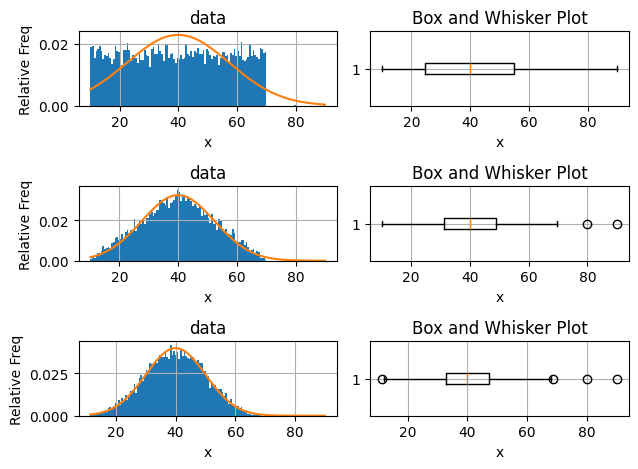

```python
#Create a three datasets with different spreads and with outliers.
g01 = normalRandomGenerator(dataLength=9999,numberSamples=1,lowLim=10,highLim=70,seed=1) + [68.5] + [80] + [90]
g02 = normalRandomGenerator(dataLength=9999,numberSamples=2,lowLim=10,highLim=70,seed=1) + [68.5] + [80] + [90]
g03 = normalRandomGenerator(dataLength=9999,numberSamples=3,lowLim=10,highLim=70,seed=1) + [68.5] + [80] + [90]

#Create a figure with three rows and two columns
fig,axes = plt.subplots(3,2)

#Call the plotHistAndBox function to process the first dataset
plotHistAndBox(g01,axes,axesRow=0,multiDim=True)

#Process the second dataset
plotHistAndBox(g02,axes,axesRow=1,multiDim=True)

#Process the third dataset
plotHistAndBox(g03,axes,axesRow=2,multiDim=True)


axes[0,0].grid(True)
axes[0,1].grid(True)
axes[1,0].grid(True)
axes[1,1].grid(True)
axes[2,0].grid(True)
axes[2,1].grid(True)
plt.tight_layout()
plt.savefig("StatisticsPart02.12.png")
plt.show()
```

## **Description of the image shown above, StatisticsPart02.12.png**

### 1. Type of image

A three‑row figure in which each row contains a histogram with an overlaid density curve on the left and a box‑and‑whisker plot on the right.

### 2. Overall summary

The figure compares three different datasets that share the same outlier values but differ in their overall spread. Each row shows a histogram paired with a box‑and‑whisker plot for the same dataset. The histograms illustrate the distribution shape and how closely each dataset approximates a normal distribution, while the box‑and‑whisker plots highlight differences in center, spread, and outliers. This example demonstrates how box‑and‑whisker plots provide an immediate visual comparison across multiple datasets.

### 3. Detailed description

The figure contains three horizontal pairs of plots:

**Top row:**  
The histogram shows a relatively wide distribution with moderate variation across the x‑axis. A smooth curve overlays the bars. It is a poor match for the nearly flat distribution The corresponding box‑and‑whisker plot shows a wide interquartile range (IQR), long whiskers, and no visible outliers.

**Middle row:**  
The histogram displays a distribution that is closer to normal, with a more pronounced central peak. The overlaid curve follows the histogram closely. The box‑and‑whisker plot shows a narrower IQR than the top row and includes two outliers on the high end, marked as individual points beyond the right whisker.

**Bottom row:**  
The histogram shows an even more sharply peaked distribution, indicating a smaller standard deviation. The overlaid curve is tall and narrow. The box‑and‑whisker plot reflects this reduced spread with a tight IQR and short whiskers. Four outliers appear—one on the low end and three on the high end—indicating that the same extreme values stand out more clearly when the dataset’s spread is small.

All histograms use the labels:

All box‑and‑whisker plots use the label:

- Horizontal axis: “x”

### 4. Purpose of the image

The purpose of this image is to illustrate how box‑and‑whisker plots help compare multiple datasets that differ in spread but share the same outlier values. The example shows that:

- The center (median), spread (IQR), and overall range are immediately visible in each box plot.
- Outliers become more or less prominent depending on the dataset’s variability.
- Normal curves overlaid on the histograms show how closely each dataset approximates a normal distribution.

This visualization reinforces why box‑and‑whisker plots are powerful tools for comparing distributions, especially when analyzing differences in spread and identifying outliers across multiple datasets.

## Probability of a value within one sigma of the mean

Experimentally find and print the probability that a value in a data set with a near-normal distribution will be within one sigma on each side of the mean. Express the probability as a percentage with no decimal.

```python
data = normalRandomGenerator(dataLength=1000,numberSamples=49,lowLim=0,highLim=1000)
xBar = mean(data)
print("xBar =",xBar)
stDev = stdev(data)
print("stdev =", stDev)
lowLimit = xBar - stDev
print("lowLimit =",lowLimit)
highLimit = xBar + stDev
print("highLimit =",highLimit)
lowZ = (lowLimit - xBar)/stDev
print("lowZ =",lowZ)
highZ = (highLimit - xBar)/stDev
print("highZ =",highZ)
probability = cumulativeDistribution(highZ) - cumulativeDistribution(lowZ)
print("probability that x is within one sigma =",int(probability*100//1),"percent")
```

```
xBar = 500.1666185602021
stdev = 41.56617034378628
lowLimit = 458.6004482164158
highLimit = 541.7327889039884
lowZ = -0.9999999999999997
highZ = 1.000000000000001
probability that x is within one sigma = 68 percent
```

## Probability of a value within two sigma of the mean

Experimentally find and print the probability that a value in a data set with a near-normal distribution will be within two sigma on each side of the mean. Express the probability as a percentage with no decimal.

```python
data = normalRandomGenerator(dataLength=1000,numberSamples=49,lowLim=0,highLim=1000)
xBar = mean(data)
print("xBar =",xBar)
stDev = stdev(data)
print("stdev =", stDev)
lowLimit = xBar - 2*stDev
print("lowLimit =",lowLimit)
highLimit = xBar + 2*stDev
print("highLimit =",highLimit)
lowZ = (lowLimit - xBar)/stDev
print("lowZ =",lowZ)
highZ = (highLimit - xBar)/stDev
print("highZ =",highZ)
probability = cumulativeDistribution(highZ) - cumulativeDistribution(lowZ)
print("probability that x is within two sigma =",int(probability*100//1),"percent")
```

```
xBar = 500.1666185602021
stdev = 41.56617034378628
lowLimit = 417.03427787262956
highLimit = 583.2989592477746
lowZ = -1.9999999999999993
highZ = 1.9999999999999993
probability that x is within two sigma = 95 percent
```

--To be continued in the tutorial titled Statistics Exercises Part 3--

Author: Prof. Richard G. Baldwin, Austin Community College, Austin, TX

File: StatisticsPart02.ipynb

Revised: 02/23/26

Copyright 2018 Richard G. Baldwin

-end-